# FinanceSocial-Subjectivity

JoanneStasiak

3/8/2021

Introduce the packages we need

```r
library(simr)
library(tidyr)#for changing from long to wide//vice versa
library(ggpubr)
```

```r
library(lme4)
library(sjPlot)#for interactions
library(ggridges)
library(jtools)
library(ggplot2)#for pretty plots
library(viridis)
library(dplyr)#for recoding df
library(interactions)#for interaction plots
library(effects)
library(hrbrthemes)## for glmer & lmer power analysis
```

Transform some of the data

```r
#Read in the data
longDF <- read.csv("FinanceS_SubjectiveObjective_LongData_NA.csv")#this is just bringing in those csv's and giving it a shorter name (longDF and wideDF), this file^ only has the subjectivity data, not the other individual difference measures

wideDF <- read.csv("Qualtrics_TotalScores.csv")#this file has the individual difference measures and the averaged behavioral activity


#Convert to factors - we're only doing this to the columns with words/phrases that do not have numerical value
longDF$PID <- as.factor(longDF$PID)
longDF$Gender <- as.factor(longDF$Gender)
longDF$Ethnicity <- as.factor(longDF$Ethnicity)
longDF$Activity <- as.factor(longDF$Activity)
longDF$Info <- as.factor(longDF$Info)

wideDF$PID <- as.factor(wideDF$ProlificPID)
wideDF$Gender <- as.factor(wideDF$Gender)
wideDF$Ethnicity <- as.factor(wideDF$Ethnicity)
wideDF$WorkingOut_Info <- as.factor(wideDF$WorkingOut_Info)
wideDF$EatingHealthy_Info <- as.factor(wideDF$EatingHealthy_Info)
wideDF$ControllingFeelings_Info <- as.factor(wideDF$ControllingFeelings_Info)
wideDF$RunningMile_Info <- as.factor(wideDF$RunningMile_Info)
wideDF$DrawingBicycle_Info <- as.factor(wideDF$DrawingBicycle_Info)
wideDF$LearnLanguage_Info <- as.factor(wideDF$LearnLanguage_Info)
wideDF$SavingMoney_Info <- as.factor(wideDF$SavingMoney_Info)
wideDF$Driving_Info <- as.factor(wideDF$Driving_Info)
wideDF$Caring_Info <- as.factor(wideDF$Caring_Info)
wideDF$ActEthic_Info <- as.factor(wideDF$ActEthic_Info)
wideDF$DoingMath_Info <- as.factor(wideDF$DoingMath_Info)

#wideDF #this displays the data
#longDF
```

Let’s first look only at the subjectivity data

```r
#We can use some descriptive statistics to see how people on average assess the different activities

#Get mean of all ratings and activities
data <- longDF %>%
  group_by(Activity) %>%
  get_summary_stats(Ability, Confidence, Experience, Effort, Subjectivity, type = "mean_se")#this also gets "se" or standard error - we need that for the error bars in our bar plot
data#shows the new, summarized data
```

```
## # A tibble: 55 x 5
##    Activity          variable         n  mean    se
##    <fct>             <chr>        <dbl> <dbl> <dbl>
##  1 Acting Ethically  Ability         49  5.31 0.146
##  2 Acting Ethically  Confidence      49  5.49 0.17
##  3 Acting Ethically  Effort          49  3.26 0.162
##  4 Acting Ethically  Experience      49  3.84 0.102
##  5 Acting Ethically  Subjectivity    49  3.49 0.249
##  6 Caring for Others Ability         49  5.04 0.212
##  7 Caring for Others Confidence      49  5.49 0.191
##  8 Caring for Others Effort          49  3.45 0.17
##  9 Caring for Others Experience      49  3.86 0.146
## 10 Caring for Others Subjectivity    49  3.08 0.238
## # ... with 45 more rows
```

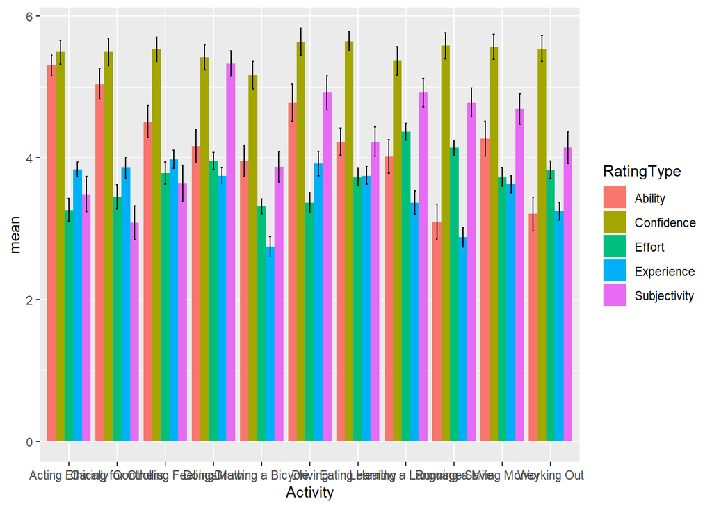

```r
data$n <- NULL #unnecessary
data <- data %>% #rename one of the columns
  rename(
    RatingType = variable,
    )
#data


#Ratings Meanings
#1=Below average, 7=above average
#1=Not at ll confident, 7=Very confident
#1=No experience, 7=Very much experience
#1=No effort, 7=Very much effort
#1=Entirely subjective, 7=Entirely objective

# Error bars represent standard error of the mean
ggplot(data, aes(x=Activity, y=mean, fill=RatingType)) +
    geom_bar(position=position_dodge(), stat="identity") +
    geom_errorbar(aes(ymin=mean-se, ymax=mean+se),
                  width=.2,                    # Width of the error bars
                  position=position_dodge(.9))
```

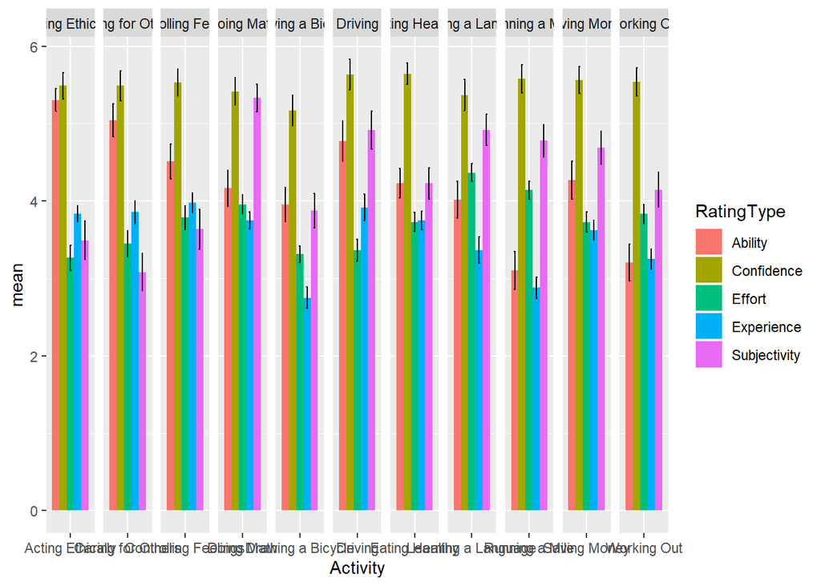

```r
#Look at the ratings grouped by the activity
p<-ggplot(data, aes(x=Activity, y=mean, fill=RatingType)) +
    geom_bar(position=position_dodge(), stat="identity") +
    geom_errorbar(aes(ymin=mean-se, ymax=mean+se),
                  width=.2,                    # Width of the error bars
                  position=position_dodge(.9))
p+facet_grid(~Activity, scales = "free_x")
```

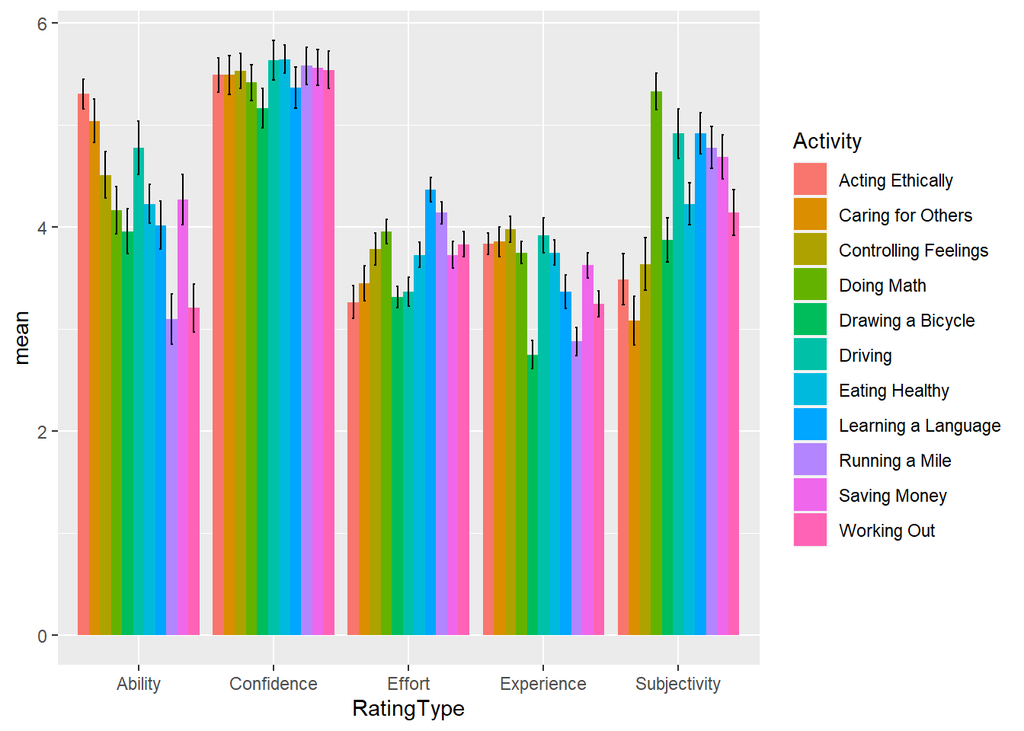

```r
ggsave(file="gridRatingsxActivity.pdf", width=20, height=4, dpi=300)



#Let's look at the data grouped by rating type
ratings_plot<-ggplot(data, aes(x=RatingType, y=mean, fill=Activity)) +
    geom_bar(position=position_dodge(), stat="identity") +
    geom_errorbar(aes(ymin=mean-se, ymax=mean+se),
                  width=.2,                    # Width of the error bars
                  position=position_dodge(.9))
ratings_plot
```

```r
#transform from long to wide format, with Rating Type as the dependent variable
data$se <- NULL
data_wide_RT <- spread(data, Activity, mean)
data_wide_RT
```

```
## # A tibble: 5 x 12
##   RatingType `Acting Ethical~ `Caring for Oth~ `Controlling Fe~ `Doing Math`
##   <chr>                 <dbl>            <dbl>            <dbl>        <dbl>
## 1 Ability                5.31             5.04             4.51         4.17
## 2 Confidence             5.49             5.49             5.53         5.42
## 3 Effort                 3.26             3.45             3.79         3.96
## 4 Experience             3.84             3.86             3.98         3.75
## 5 Subjectiv~             3.49             3.08             3.64         5.33
## # ... with 7 more variables: `Drawing a Bicycle` <dbl>, Driving <dbl>, `Eating
## #   Healthy` <dbl>, `Learning a Language` <dbl>, `Running a Mile` <dbl>,
## #   `Saving Money` <dbl>, `Working Out` <dbl>
```

```r
#transform from long to wide format, with Activity as the dependent variable
data_wide_Act <- spread(data, RatingType, mean)#I haven't used this in analyses, it's just another way to visualize our data
data_wide_Act#display the transformed data
```

```
## # A tibble: 11 x 6
##    Activity             Ability Confidence Effort Experience Subjectivity
##    <fct>                  <dbl>      <dbl>  <dbl>      <dbl>        <dbl>
##  1 Acting Ethically        5.31       5.49   3.26       3.84         3.49
##  2 Caring for Others       5.04       5.49   3.45       3.86         3.08
##  3 Controlling Feelings    4.51       5.53   3.79       3.98         3.64
##  4 Doing Math              4.17       5.42   3.96       3.75         5.33
##  5 Drawing a Bicycle       3.96       5.17   3.31       2.75         3.88
##  6 Driving                 4.78       5.63   3.37       3.92         4.92
##  7 Eating Healthy          4.23       5.65   3.73       3.75         4.23
##  8 Learning a Language     4.02       5.37   4.37       3.37         4.92
##  9 Running a Mile          3.1        5.58   4.14       2.88         4.78
## 10 Saving Money            4.27       5.56   3.73       3.62         4.69
## 11 Working Out             3.21       5.54   3.83       3.25         4.15
```

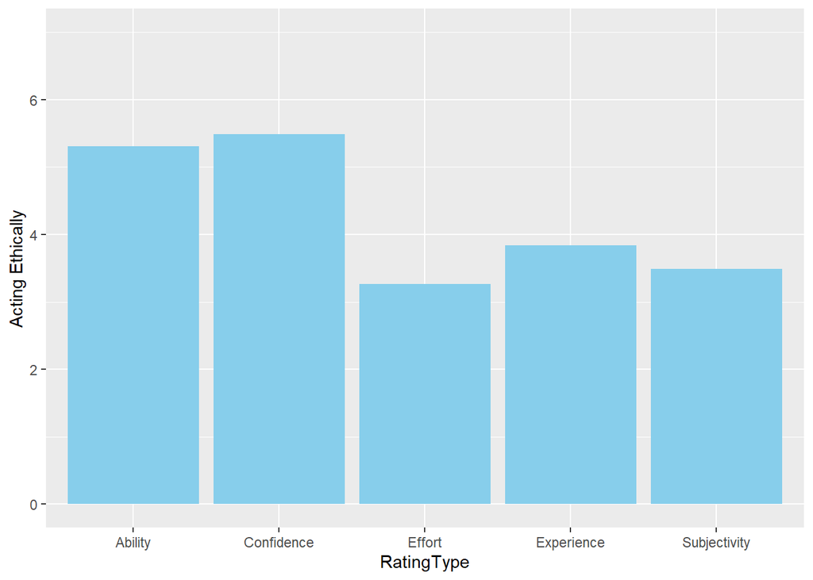

```r
#Look at one activity separately - in this case we're looking at "Acting Ethically" - you can sub out the activity for any one you like! Just note the weird ` ` objects surrounding the y variable
data_wide_RT$RatingType <- as.factor(data_wide_RT$RatingType)
p<-ggplot(data_wide_RT, aes(x=RatingType, y=`Acting Ethically`)) +
    geom_bar(position=position_dodge(), stat="identity", fill = "skyblue") + ylab("Acting Ethically")
p+ylim(0,7)
```

Let’s do some analyses! Are some ratings associated with others? Do some ratings greatly differ from others?

```r
#Let's first run some easy correlations
#How may one's perceived ability and one's confidence of one's same ability be associated?
cor.test(longDF$Confidence, longDF$Ability)#it doesn't matter what order we list our variables, we just want to see if any relationship exists between them
```

```
##
##  Pearson's product-moment correlation
##
## data:  longDF$Confidence and longDF$Ability
## t = 2.4999, df = 531, p-value = 0.01272
## alternative hypothesis: true correlation is not equal to 0
## 95 percent confidence interval:
##  0.02313665 0.19103540
## sample estimates:
##      cor
## 0.107855
```

```r
#run the above correlation as a regression- this will give us essentially the same output, it is just more legit (we are asking how confident participants are in their assessments of their ability, so we can't treat the two measures as independent, which is what correlations do)

model<-lm(Confidence~Ability, data=longDF)#here the order matters a little more - we are asking how one variable predicts another, in this case, how does one's reported ability affect how confident they are in that assessment?
#the above model is the same as (y ~ x), or "y as predicted by x", or "the dependent variable as predicted by the independent variable"
summary(model) #this will give us the stats for that above model (Intercept, slope, p-value, t-value)
```

```
##
## Call:
## lm(formula = Confidence ~ Ability, data = longDF)
##
## Residuals:
##     Min      1Q  Median      3Q     Max
## -4.4746 -0.5550 -0.2332  1.2840  1.7668
##
## Coefficients:
##             Estimate Std. Error t value Pr(>|t|)
## (Intercept)  5.15269    0.14666   35.13   <2e-16 ***
## Ability      0.08047    0.03219    2.50   0.0127 *
## ---
## Signif. codes:  0 '***' 0.001 '**' 0.01 '*' 0.05 '.' 0.1 ' ' 1
##
## Residual standard error: 1.25 on 531 degrees of freedom
## Multiple R-squared:  0.01163,    Adjusted R-squared:  0.009771
## F-statistic:  6.25 on 1 and 531 DF,  p-value: 0.01272
```

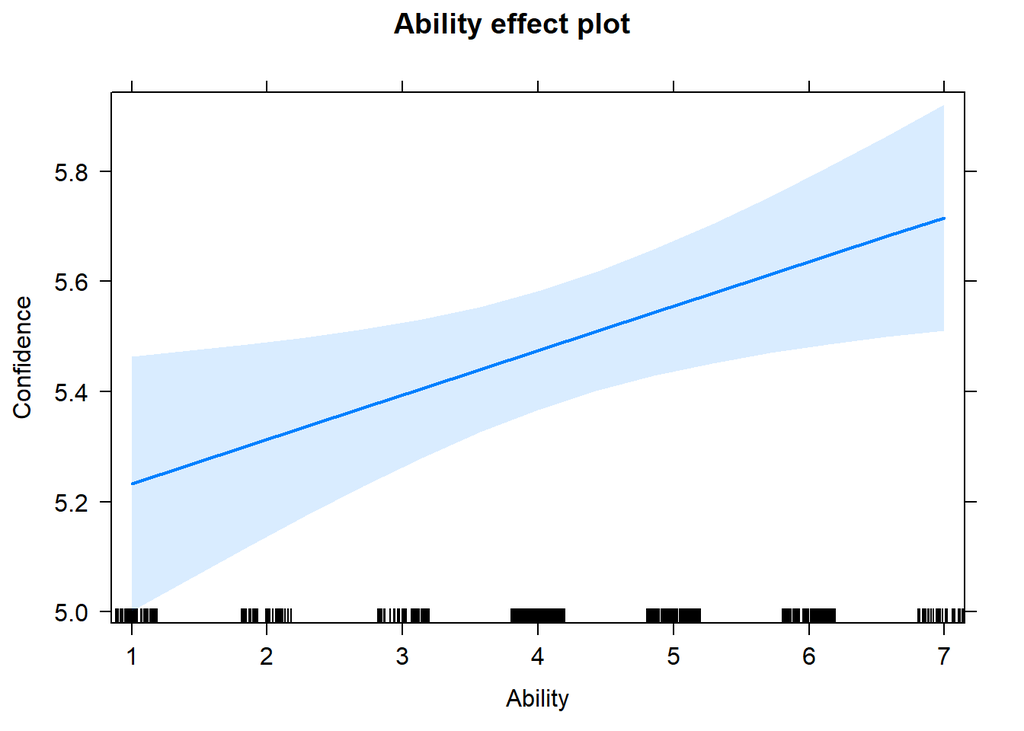

```r
plot(effect("Ability", model, main=""))#this will give us a really basic plot of the model, note that this does not account for repeated observations!
```

```r
#So let's account for repeated observations! Now we can use a linear mixed effects regression (lmer) to address the multiple data points from each participant. We only need to add a "+ (1|PID)" to the model, as seen below
model_lmer <- lmer(Confidence~Ability + (1|PID), data=longDF)
summary(model_lmer)#We can use these stats to create a visualization of this data! We need the stats from the Intercept and the Slope - the slope is the number directly below the intercept value
```

```
## Linear mixed model fit by REML ['lmerMod']
## Formula: Confidence ~ Ability + (1 | PID)
##    Data: longDF
##
## REML criterion at convergence: 1618
##
## Scaled residuals:
##     Min      1Q  Median      3Q     Max
## -3.7844 -0.5628  0.1630  0.6850  2.3223
##
## Random effects:
##  Groups   Name        Variance Std.Dev.
##  PID      (Intercept) 0.578    0.7603
##  Residual             1.005    1.0024
## Number of obs: 533, groups:  PID, 49
##
## Fixed effects:
##             Estimate Std. Error t value
## (Intercept)  5.13848    0.16857  30.482
## Ability      0.08215    0.02867   2.866
##
## Correlation of Fixed Effects:
##         (Intr)
## Ability -0.720
```

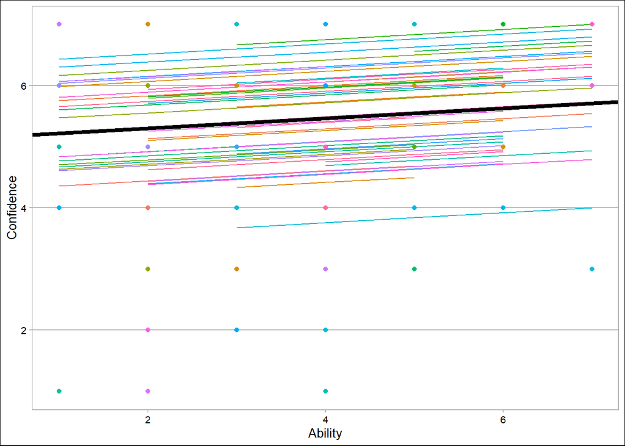

```r
longDF$Predictions <- NA #this creates a new column in our data frame
longDF$Predictions <- predict(model_lmer) #this fills that column using the model we previously made
confidenceXability <- ggplot(aes(x = Ability, y = Predictions, color = as.factor(PID)), data = longDF) +
  geom_line(size=.5) +
  geom_point(aes(y = Confidence)) +
  geom_abline(slope= 0.08210, intercept=5.13572,lwd= 1.5,col = 'black') +#this is where we have to update the stats, we need to add the values of the slope and the intercept of the model we ran so that we can make an accurate graph!
  xlab("Ability") + #whatever you want to call the x -axis -- this does not have to be syntactically the same as your x variable, for example, we could call this "Self-Reported Ability at Activities"
  ylab("Confidence") +#same deal for the y axis!
  ggthemes::theme_calc()+
  theme(legend.position = "none")
confidenceXability#this displays the graph
```

How does activity type play a role?

```r
#Now we can start to run interaction analyses - while we may have two measures that are associated to each other writ large, there is probably a lot of variance based on the activity that is being reported on!

model_lmer_interaction <- lmer(Confidence~Ability * Activity + (1|PID), data=longDF)# We can easily add a "*Activity " to our previous model to account for the different responses for each activity
summary(model_lmer_interaction)#gives us the stats for the model
```

```
## Linear mixed model fit by REML ['lmerMod']
## Formula: Confidence ~ Ability * Activity + (1 | PID)
##    Data: longDF
##
## REML criterion at convergence: 1623.5
##
## Scaled residuals:
##     Min      1Q  Median      3Q     Max
## -4.0014 -0.5511  0.1028  0.6189  2.6450
##
## Random effects:
##  Groups   Name        Variance Std.Dev.
##  PID      (Intercept) 0.5181   0.7198
##  Residual             0.9767   0.9883
## Number of obs: 533, groups:  PID, 49
##
## Fixed effects:
##                                      Estimate Std. Error t value
## (Intercept)                           2.94922    0.78987   3.734
## Ability                               0.47880    0.14518   3.298
## ActivityCaring for Others             0.54071    0.92907   0.582
## ActivityControlling Feelings          1.87037    0.90468   2.067
## ActivityDoing Math                    2.28656    0.88716   2.577
## ActivityDrawing a Bicycle             2.12682    0.88197   2.411
## ActivityDriving                       2.30431    0.88384   2.607
## ActivityEating Healthy                2.48965    0.93642   2.659
## ActivityLearning a Language           1.62836    0.87434   1.862
## ActivityRunning a Mile                3.10954    0.83800   3.711
## ActivitySaving Money                  2.23859    0.88054   2.542
## ActivityWorking Out                   2.65747    0.84899   3.130
## Ability:ActivityCaring for Others    -0.08207    0.17370  -0.472
## Ability:ActivityControlling Feelings -0.32969    0.17362  -1.899
## Ability:ActivityDoing Math           -0.43545    0.17283  -2.520
## Ability:ActivityDrawing a Bicycle    -0.46068    0.17437  -2.642
## Ability:ActivityDriving              -0.39941    0.16609  -2.405
## Ability:ActivityEating Healthy       -0.43730    0.18609  -2.350
## Ability:ActivityLearning a Language  -0.28236    0.17076  -1.654
## Ability:ActivityRunning a Mile       -0.63094    0.16833  -3.748
## Ability:ActivitySaving Money         -0.39387    0.16981  -2.319
## Ability:ActivityWorking Out          -0.49117    0.17194  -2.857
```

```
##
## Correlation matrix not shown by default, as p = 22 > 12.
## Use print(x, correlation=TRUE)  or
##     vcov(x)        if you need it
```

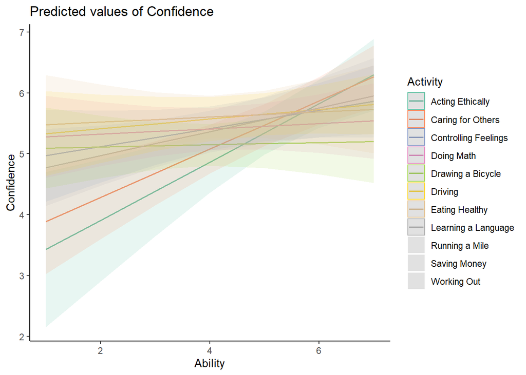

```r
#sim_slopes(model_lmer_interaction, pred = Ability, modx =Activity, johnson_neyman = FALSE)#get the slopes of all of the different relationships
plot_model(model_lmer_interaction, type = "int", colors = "Set2")+theme_classic()#this gives us a messy plot of all of the slopes laid on top of each other - but it is hard to differentiate all of them!
```

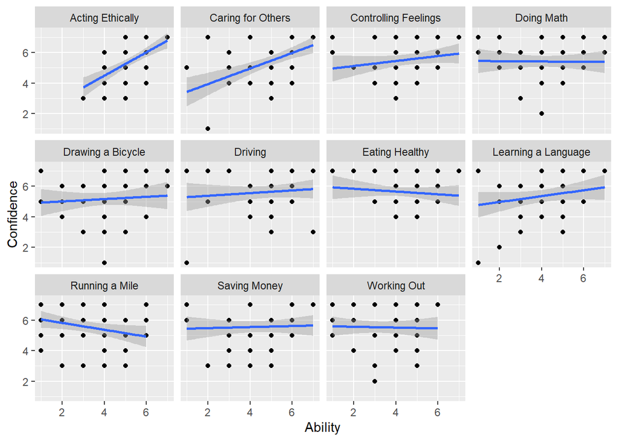

```r
qplot(x = Ability, y = Confidence, facets = ~Activity, data = longDF) +
  geom_smooth(method = "lm")#this divides that same plot into multiple squares so we can see how all those slopes vary
```

Repeat with the other measures

```r
#Ability and Subjectivity

able_Subj <- lmer(Subjectivity~Ability + (1|PID), data=longDF)
summary(able_Subj)
```

```
## Linear mixed model fit by REML ['lmerMod']
## Formula: Subjectivity ~ Ability + (1 | PID)
##    Data: longDF
##
## REML criterion at convergence: 2056.9
##
## Scaled residuals:
##      Min       1Q   Median       3Q      Max
## -2.55817 -0.69066 -0.07286  0.83384  2.06128
##
## Random effects:
##  Groups   Name        Variance Std.Dev.
##  PID      (Intercept) 0.2361   0.4859
##  Residual             2.5806   1.6064
## Number of obs: 533, groups:  PID, 49
##
## Fixed effects:
##             Estimate Std. Error t value
## (Intercept)  4.42330    0.21006   21.06
## Ability     -0.03288    0.04384   -0.75
##
## Correlation of Fixed Effects:
##         (Intr)
## Ability -0.884
```

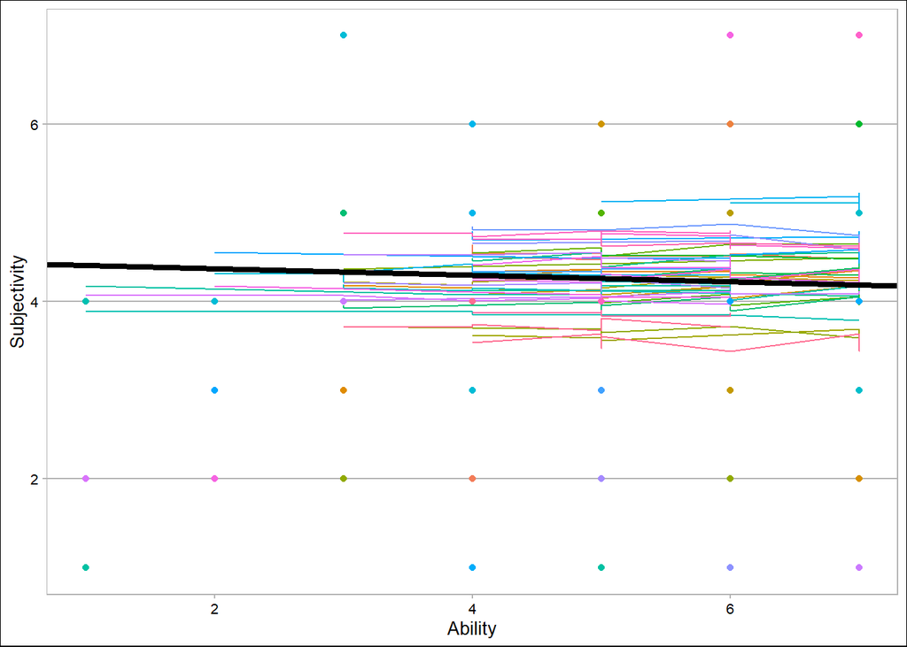

```r
longDF$Predictions <- NA
longDF$Predictions <- predict(able_Subj)
subjectivityXability <- ggplot(aes(x = Confidence, y = Predictions, color = as.factor(PID)), data = longDF) +
  geom_line(size=.5) +
  geom_point(aes(y = Ability)) +
  geom_abline(slope= -0.03641, intercept=4.44162,lwd= 1.5,col = 'black') +
  xlab("Ability") +
  ylab("Subjectivity") +
  ggthemes::theme_calc()+
  theme(legend.position = "none")
subjectivityXability
```

```r
#Run more Moderation analyses
ableSubj_interaction <- lmer(Subjectivity~Ability * Activity + (1|PID), data=longDF)
summary(ableSubj_interaction)
```

```
## Linear mixed model fit by REML ['lmerMod']
## Formula: Subjectivity ~ Ability * Activity + (1 | PID)
##    Data: longDF
##
## REML criterion at convergence: 1971.2
##
## Scaled residuals:
##     Min      1Q  Median      3Q     Max
## -3.1773 -0.7137  0.0879  0.6822  2.9734
##
## Random effects:
##  Groups   Name        Variance Std.Dev.
##  PID      (Intercept) 0.2402   0.4901
##  Residual             2.1400   1.4629
## Number of obs: 533, groups:  PID, 49
##
## Fixed effects:
##                                      Estimate Std. Error t value
## (Intercept)                           3.35278    1.14399   2.931
## Ability                               0.02582    0.21156   0.122
## ActivityCaring for Others            -1.40718    1.36239  -1.033
## ActivityControlling Feelings         -0.67084    1.32213  -0.507
## ActivityDoing Math                    1.94302    1.29296   1.503
## ActivityDrawing a Bicycle             0.09403    1.28864   0.073
## ActivityDriving                       0.86956    1.29044   0.674
## ActivityEating Healthy                0.10359    1.36504   0.076
## ActivityLearning a Language           1.64926    1.27462   1.294
## ActivityRunning a Mile                2.11214    1.22230   1.728
## ActivitySaving Money                  1.00080    1.28402   0.779
## ActivityWorking Out                   0.94689    1.23810   0.765
## Ability:ActivityCaring for Others     0.19954    0.25463   0.784
## Ability:ActivityControlling Feelings  0.18678    0.25369   0.736
## Ability:ActivityDoing Math           -0.01883    0.25164  -0.075
## Ability:ActivityDrawing a Bicycle     0.08249    0.25465   0.324
## Ability:ActivityDriving               0.11993    0.24233   0.495
## Ability:ActivityEating Healthy        0.15700    0.27109   0.579
## Ability:ActivityLearning a Language  -0.04663    0.24871  -0.187
## Ability:ActivityRunning a Mile       -0.24744    0.24526  -1.009
## Ability:ActivitySaving Money          0.05212    0.24740   0.211
## Ability:ActivityWorking Out          -0.06788    0.25043  -0.271
```

```
##
## Correlation matrix not shown by default, as p = 22 > 12.
## Use print(x, correlation=TRUE)  or
##     vcov(x)        if you need it
```

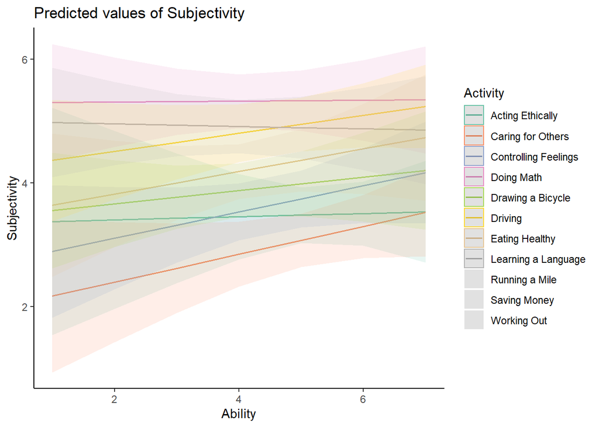

```r
#sim_slopes(ableSubj_interaction, pred = Ability, modx =Activity, johnson_neyman = FALSE)#get the slopes of all of the different relationships
plot_model(ableSubj_interaction, type = "int", colors = "Set2")+theme_classic()
```

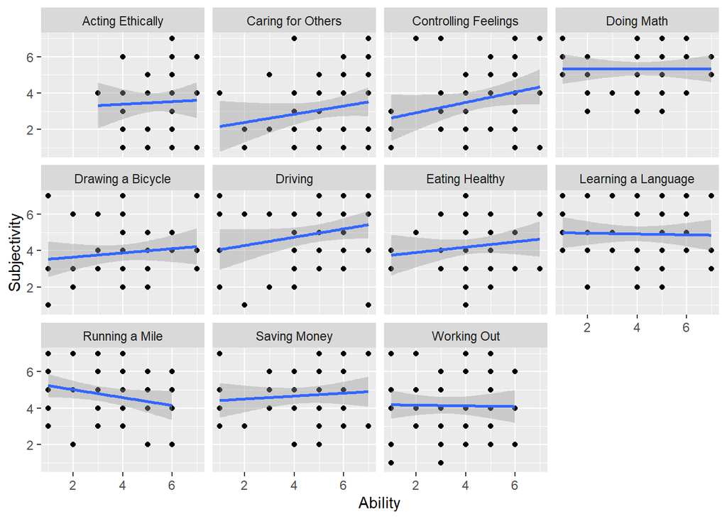

```r
qplot(x = Ability, y = Subjectivity, facets = ~Activity, data = longDF) +
  geom_smooth(method = "lm")
```

Other potential analyses with this subset of data:

Confidence x Subjectivity Experience x Ability Subjectivity x Effort Subjectivity x Experience Effort x Ability …and infinitely more

All possible vars: Ability, Effort, Experience, Confidence, Subjectivity, Info Source

[output not shown]

How may these assessments track with individual differences? - - This is now using the ‘wideDF’ dataframe instead of longDF!

```r
#Run some analyses - this one is for general self-efficacy
#So here we're looking at the interaction of self-efficacy on the relationship between Confidence and Subjectivity
mlm_Objectivity_Confidence_GSE <- lm(SubjectivityAvg~ConfidenceAvg * General.Self.Efficacy, data =wideDF)
summary(mlm_Objectivity_Confidence_GSE)#insignificant, womp womp
```

```
##
## Call:
## lm(formula = SubjectivityAvg ~ ConfidenceAvg * General.Self.Efficacy,
##     data = wideDF)
##
## Residuals:
##      Min       1Q   Median       3Q      Max
## -1.55555 -0.36867 -0.06557  0.49144  1.46327
##
## Coefficients:
##                                     Estimate Std. Error t value Pr(>|t|)
## (Intercept)                          5.18757    4.02460   1.289    0.204
## ConfidenceAvg                       -0.15882    0.68368  -0.232    0.817
## General.Self.Efficacy               -0.07052    0.13524  -0.521    0.605
## ConfidenceAvg:General.Self.Efficacy  0.01264    0.02284   0.553    0.583
##
## Residual standard error: 0.6828 on 45 degrees of freedom
## Multiple R-squared:  0.07402,    Adjusted R-squared:  0.01229
## F-statistic: 1.199 on 3 and 45 DF,  p-value: 0.3209
```

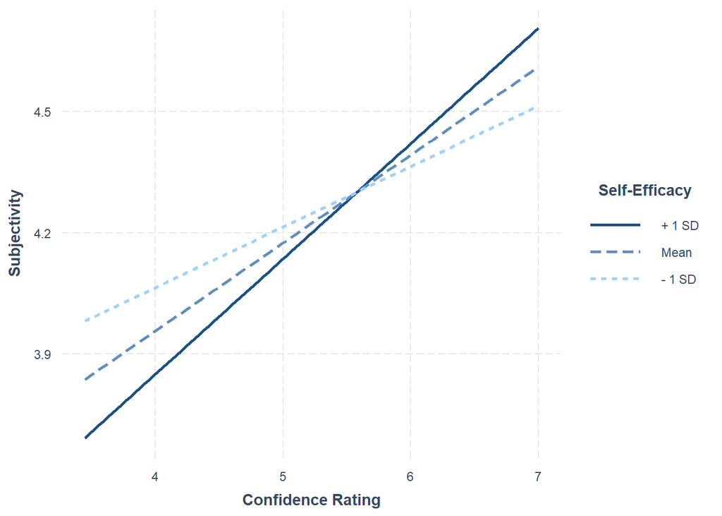

```r
ModerationPlot <- interact_plot(mlm_Objectivity_Confidence_GSE, pred = ConfidenceAvg, modx = General.Self.Efficacy, x.label= "Confidence Rating", y.label = "Subjectivity", legend.main="Self-Efficacy")
ModerationPlot#we can see this relationship visualized, while it is usually a good sign that the lines cross, there is probably too much variance in the model, which is making it insignificant
```

```r
sim_slopes(mlm_Objectivity_Confidence_GSE, pred = ConfidenceAvg, modx =General.Self.Efficacy, johnson_neyman = FALSE)#get the slopes of all of the different relationships
```

```
## SIMPLE SLOPES ANALYSIS
##
## Slope of ConfidenceAvg when General.Self.Efficacy = 24.42 (- 1 SD):
##
##   Est.   S.E.   t val.      p
## ------ ------ -------- ------
##   0.15   0.17     0.90   0.37
##
## Slope of ConfidenceAvg when General.Self.Efficacy = 29.78 (Mean):
##
##   Est.   S.E.   t val.      p
## ------ ------ -------- ------
##   0.22   0.12     1.80   0.08
##
## Slope of ConfidenceAvg when General.Self.Efficacy = 35.13 (+ 1 SD):
##
##   Est.   S.E.   t val.      p
## ------ ------ -------- ------
##   0.29   0.18     1.61   0.11
```

Other potential analyses:

DOSPERT_Financial x Saving Money Ability IRI.Total x Caring for Others? DERS x Controlling Feelings

Possible Individual Differences to look at: Impulsiveness (BIS, CFC), Self-Efficacy (General, Academic), Empathy (IRI), Risk (DOSPERT), Difficulties in Emotion Regulation (DERS)

```r
#Run some more analyses - now we're looking at how Difficulties in Emotion Regulation (DERS) may predict being able to control one's feelings
mlm_DERS_ControlFeelings<- lm(ControllingFeelings_Ability~DERS_total, data =wideDF)
summary(mlm_DERS_ControlFeelings)#this is significant!!And a negative association! Which makes sense!It is saying that individuals who have greater difficulty regulating their emotions, also tend to report not being good at controlling their feelings - it is great to have consistency across measures!
```

```
##
## Call:
## lm(formula = ControllingFeelings_Ability ~ DERS_total, data = wideDF)
##
## Residuals:
##      Min       1Q   Median       3Q      Max
## -2.36247 -0.97923 -0.09488  1.02301  2.78948
##
## Coefficients:
##              Estimate Std. Error t value Pr(>|t|)
## (Intercept)  7.564176   0.670747  11.277 5.75e-15 ***
## DERS_total  -0.038548   0.008091  -4.764 1.86e-05 ***
## ---
## Signif. codes:  0 '***' 0.001 '**' 0.01 '*' 0.05 '.' 0.1 ' ' 1
##
## Residual standard error: 1.28 on 47 degrees of freedom
## Multiple R-squared:  0.3256, Adjusted R-squared:  0.3113
## F-statistic:  22.7 on 1 and 47 DF,  p-value: 1.859e-05
```

```
## geom_path: Each group consists of only one observation. Do you need to adjust
## the group aesthetic?
```

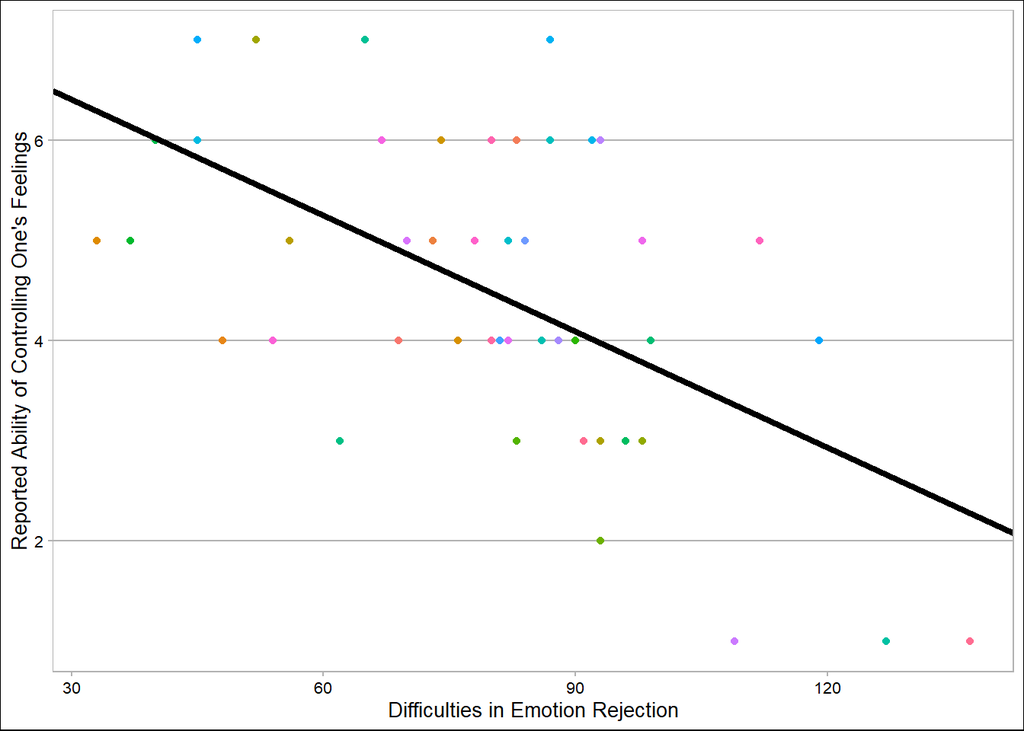

```r
wideDF$Predictions <- NA
wideDF$Predictions <- predict(mlm_DERS_ControlFeelings)
dersXcontrolFeelings <- ggplot(aes(x = DERS_total, y = Predictions, color = as.factor(PID)), data = wideDF) +
  geom_line(size=.5) +
  geom_point(aes(y = ControllingFeelings_Ability)) +
  geom_abline(slope= -0.038548, intercept=7.564176,lwd= 1.5,col = 'black') +
  xlab("Difficulties in Emotion Rejection") +
  ylab("Reported Ability of Controlling One's Feelings") +
  ggthemes::theme_calc()+
  theme(legend.position = "none")
dersXcontrolFeelings
```

Run analyses with Behavioral Data!

Possibly: Finance Tips_FinanceName x Caring Ability // Acting Ethically Ability controlling feelings and iri (empathy)…

~~~~

Shay’s Analyses!

```r
#Run some analyses - this one is for empathy and caring for others
CaringAbility_IRI <- lm(Caring_Ability~ IRI.Total, data =wideDF)
summary(CaringAbility_IRI)#Significant!! Awesome!!! People who tend to be more empathic also report being better at caring for others!
```

```
##
## Call:
## lm(formula = Caring_Ability ~ IRI.Total, data = wideDF)
##
## Residuals:
##     Min      1Q  Median      3Q     Max
## -4.5034 -0.7951  0.1633  1.1216  2.2883
##
## Coefficients:
##             Estimate Std. Error t value Pr(>|t|)
## (Intercept)  1.12817    1.59638   0.707   0.4832
## IRI.Total    0.04167    0.01686   2.471   0.0172 *
## ---
## Signif. codes:  0 '***' 0.001 '**' 0.01 '*' 0.05 '.' 0.1 ' ' 1
##
## Residual standard error: 1.412 on 47 degrees of freedom
## Multiple R-squared:  0.115,  Adjusted R-squared:  0.09612
## F-statistic: 6.105 on 1 and 47 DF,  p-value: 0.01717
```

```
## geom_path: Each group consists of only one observation. Do you need to adjust
## the group aesthetic?
```

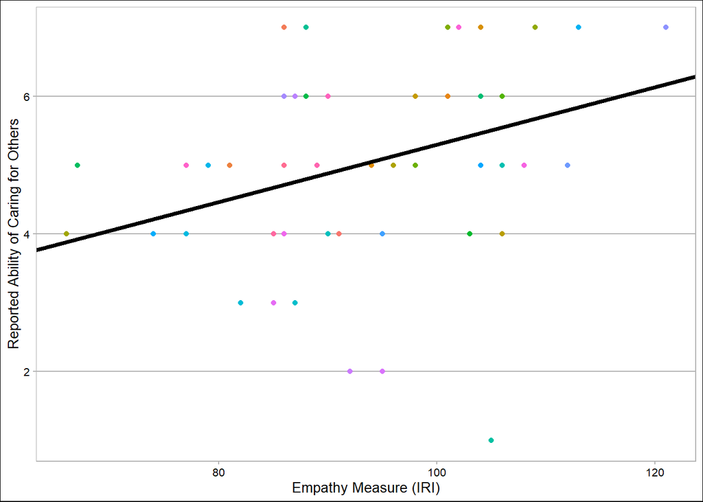

```r
#This is not supposed to have slopes for each participant (which I forgot!!) -- there are multiple slopes only when each participant has multiple observations (i.e., responses) for the same variable - in this analysis each participant has one observation for each variable (1. their self-reported ability of caring for others, and 2. their scored measure of empathy)
wideDF$Predictions <- NA
wideDF$Predictions <- predict(CaringAbility_IRI)
caringXiri <- ggplot(aes(x = IRI.Total, y = Predictions, color = as.factor(PID)), data = wideDF) +
  geom_line(size=.5) +
  geom_point(aes(y = Caring_Ability)) +
  geom_abline(slope= 0.04167, intercept=1.12817,lwd= 1.5,col = 'black') +
  xlab("Empathy Measure (IRI)") +
  ylab("Reported Ability of Caring for Others") +
  ggthemes::theme_calc()+
  theme(legend.position = "none")
caringXiri
```